# Coursework Report

*N* removed NAs: 3

*N* removed typo: 1

*N* removed <18: 23

*N* total clean: 123

| Group | *N* | *M*<sub>age</sub> | *M*<sub>rating</sub> |
| --- | --- | --- | --- |
| Control | 61 | 20.6 | 7.26 |
| Experim | 62 | 21.1 | 6.19 |

**Main analysis results**

*t*(121) = 8.04, *p* < .001

[interactive chart not shown]

[figure not shown]

[interactive chart not shown]

# Coursework Report

Analysing Data, Spring 2020

# Methods

## Participants

Table 1. Summary of mean age by group

| GROUP | n | mean | sd | min | max |
| --- | --- | --- | --- | --- | --- |
| control | 61 | 20.6 | 1.89 | 18 | 26 |
| experimental | 62 | 21.1 | 2.01 | 18 | 26 |

## Design

The present study examines whether colour influences and enhances women’s attraction to men. The dependent variable was the perceived attractiveness, which was evaluated considering three things: ‘How attractive do you think this person is?’, ‘How pleasant is this person to look at?’ and ‘If I were to meet the person in this picture face to face, I would think he is attractive.’. This was a 9-point likert scale rating variable, ranging from 1 (not attractive at all) to 9 (extremely attractive). Additionally, the independent variable or the factor in the study was the type of group in which participants were in, which had two number of levels (control and experimental group, regarding the picture’s background, white or red respectively). The conceptual hypothesis was that viewing a different colour frame around an image of a moderately attractive man influences the mean ratings of his attractiveness, and to examine this hypothesis, an independent-samples *t* test was used for statistical analysis and answers averaged to get a composite score.

# Results

The results indicated a general pattern of people in the control group (white background) to have a higher perceived attractiveness, than people in the experimental group (red background). More specifically, the mean in the control group was 7.26, while the mean in the experimental group was 6.19. The findings show a significant difference between the two conditions (*M*<sub>diff</sub> = 1.07, 95% CI [0.81, 1.34], *t* (121) = 8.04, *p* < .001). To be more specific, the high value of *t* means that the difference in the means is big compared to how much the differences between the means were expected to vary; In a signal-to-noise ratio, there is a lot signal compared to the amount of noise. Since the *p*-value is very small (<.05), there is a strong evidence against the null hypothesis. In conclusion, we should reject the null hypothesis and accept the alternative, while as shown from the increased degrees of freedom (df=121), the null hypothesis should not be retained. Finally, the confidence interval, in other words, the range of values that contain the true population value, also support this. The plot below depicts the findings; the mean attractiveness ratings of the white vs red colour groups.

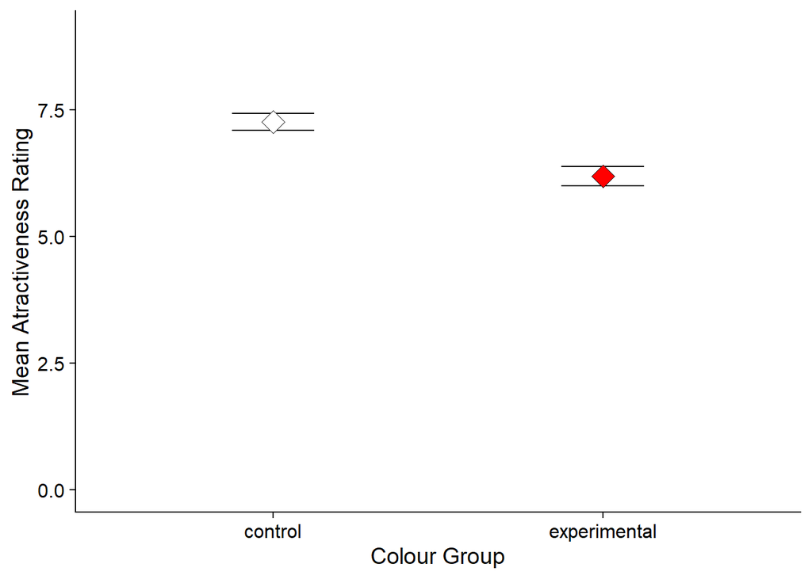

# Discussion

The difference between the results of the original study (Elliot et al., 2010), and the results of other replication studies, including ours, may be due to improper run of experiments or due to the fact that the hypothesis was supported by chance, as the study can not seem to actually be replicable. The limations were there, as people could have been biased and knew what the experiment was about.

Finally, future research should be conducted on this topic, as it is still questionable whether colour influences people’s attraction to other’s. In further research it would be suggested to recruit a larger and more diverse groups of women to gather empirical evidence with more reliable and accurately generalised findings. Moreover, future studies should use a scale for rating with larger range, to avoid imprecise answers.

To conclude, the hypothesis of the study, that women’s perceived attractiveness to men is influenced and more specifically, enhanced by the colour red, was not supported by the findings. On the other hand, results showed that control group had higher attraction to men, while experimental group indicated a lower perceived attractiveness to men. That means that Elliot’s original study was not supported by these findings and that it is not replicable. Further research is necessary to enhance the empirical evidence that already exists. Besides, the question of whether red influences attraction is still open.

# References

Elliot, A. J., Niesta Kayser, D., Greitemeyer, T., Lichtenfeld, S., Gramzow, R. H., Maier, M. A., & Liu, H. (2010). Red, rank, and romance in women viewing men. *Journal of Experimental Psychology: General, 139*(3), 399.

Francis, G. (2013). Publication bias in “Red, rank, and romance in women viewing men,” by Elliot et al. (2010). *Journal of Experimental Psychology: General, 142*(1), 292–296.